# Orai1 initial DEA

# Setup

## Goals

1. Determine the effects of Orai KO or SERCA block/ER stress (200nM thapsigargin and PKC/MAPK pathway activation (50nM PDBu) on bulk postnatal murine hippocampal culture gene expression
2. Set up a usable framework for further analysis

## Import packages

```r
library(DESeq2)
library(tidyverse)
library(parallel)
library(doParallel)
```

```r
library(BiocParallel)
library(pheatmap)
library(readxl)
library(uwot)
library(factoextra)
library(biomaRt)
library(ggsci)
library(Cairo)
library(WGCNA)
library(RColorBrewer)

source("~/utils/R/k_means_figure.R")
source("~/utils/R/pretty_MA_plot.R")
source("~/utils/R/plotPCA_manual.R")
source("~/utils/R/get_tidy_counts.R")
source("~/utils/R/go_enrichment.R")


registerDoParallel(makeCluster(12))
register(MulticoreParam(12))

set.seed(12345)

pal = pal_npg("nrc")(9)
```

# Sequence processing

## Sample sheet

Sample sheet was already added to the directory :)

## Generate fastq

~/Prakriya_Orai1_astro/211203_Orai1_bcl2fastq.sh

```bash
#!/bin/bash
#SBATCH -A b1042
#SBATCH -p genomics
#SBATCH -t 12:00:00
#SBATCH -N 1
#SBATCH --mem=48G
#SBATCH --ntasks-per-node=12
#SBATCH --mail-user=rogangrant2022@u.northwestern.edu
#SBATCH --mail-type=BEGIN,END,FAIL
#SBATCH --job-name='211203_Orai1_bcl2fastq'

module purge
cd /projects/b1038/Pulmonary/rgrant/Orai1_KO_Prakriya/211122_NB501488_0481_AH5JM2BGXK
module load bcl2fastq/2.19.1
bcl2fastq --loading-threads 4 --writing-threads 4 --processing-threads 4
```

## Generate nf-core sample sheet

```r
#get samples from file names, link to sample IDs
ss = read_csv("~/Prakriya_Orai1_astro/data/PrakriyaLab_rnaseq_sample sheet.csv",
              skip = 15,
              trim_ws = T,
              name_repair = "universal") %>%
   dplyr::select(-c(group.., Sample_Name, index:I5_Index_ID)) %>%
   dplyr::rename(sample = Sample_ID,
                 combined = group) %>%
   mutate(combined = factor(combined),
          genotype = factor(case_when(grepl("WT", combined) ~ "Wild-Type",
                                      grepl("KO", combined) ~ "Orai1 KO",
                                      TRUE ~ NA_character_)),
          treatment = factor(case_when(grepl("untreated", combined) ~ "Vehicle",
                                       grepl("treated", combined) ~ "200nM Thapsigargin + 50nM PDBu",
                                       TRUE ~ NA_character_)))
```

```
## * `group #` -> group..
```

```r
#import batch data and bind
batch_data = read_csv("~/Prakriya_Orai1_astro/data/211203_Prakriya_batch_data.csv")
ss = left_join(ss, batch_data)
fastq_files = list.files(path = "/projects/b1038/Pulmonary/rgrant/Orai1_KO_Prakriya/211122_NB501488_0481_AH5JM2BGXK/Data/Intensities/BaseCalls/MW-Prakriya_Orai1_11-15-21/",
                         pattern = "^MP.+\\.fastq\\.gz",
                         recursive = T,
                         full.names = T) %>%
   as_tibble() %>%
  #originally no column name, so add required one
  dplyr::rename(fastq_1 = value) %>%
   #only single-end, so leave empty
   mutate(fastq_2 = NA) %>%
  #location of the sample name in the file path
   dplyr::mutate(sample = substring(text = fastq_1,
                                       first = regexpr(pattern = "MP", text = fastq_1),
                                       last = (regexpr(pattern = "S\\d+_L00\\d", text = fastq_1) -  2))) %>%
   mutate(strandedness = "unstranded") %>%
   #merge with sample sheet using "Sample_ID"
   left_join(., ss)
nfcore_ss = fastq_files %>%
   dplyr::select(sample, fastq_1:strandedness)

write_csv(nfcore_ss,
          "~/Prakriya_Orai1_astro/data/211203_Prakriya_nfcore_sample_sheet.csv",
          na = "")
```

## Run pipe

```bash
screen
cd /projects/b1038/Pulmonary/rgrant/Orai1_KO_Prakriya
module purge
module load singularity
module load graphviz/2.40.1


nextflow run nf-core/rnaseq \
-r '3.4' \
-profile nu_genomics \
--email 'rogangrant2022@u.northwestern.edu' \
--genome 'GRCm38' \
-work-dir '/projects/b1042/MisharinLab/rgrant/scratch' \
--input ~/Prakriya_Orai1_astro/data/211203_Prakriya_nfcore_sample_sheet.csv
```

## Import into DESeq (simple version)

```r
#import gene conversion
mouse_conv = read_tsv("/projects/b1038/Pulmonary/rgrant/Orai1_KO_Prakriya/results/star_salmon/salmon.merged.gene_counts_length_scaled.tsv") %>%
   dplyr::select(ensembl_gene_id = gene_id, external_gene_name = gene_name)
#import des
load("/projects/b1038/Pulmonary/rgrant/Orai1_KO_Prakriya/results/star_salmon/deseq2_qc/deseq2.dds.RData")
dds = dds[, dds$sample != "MP_21_021"] #remove URNA, which we know from multiQC clusters out
tmp = colData(dds) %>%
   as.data.frame() %>%
   dplyr::select(-sizeFactor)
md_final = left_join(tmp, ss) %>%
   column_to_rownames("sample") %>%
   mutate(batch = factor(batch))
all(colnames(dds) == rownames(md_final)) #TRUE
```

```
## [1] TRUE
```

```r
des = DESeqDataSetFromMatrix(countData = counts(dds, normalized = F),
                                  colData = md_final,
                                  design = ~ combined)
```

```
##   Note: levels of factors in the design contain characters other than
##   letters, numbers, '_' and '.'. It is recommended (but not required) to use
##   only letters, numbers, and delimiters '_' or '.', as these are safe characters
##   for column names in R. [This is a message, not a warning or an error]
```

# Basic QC

## PCA

```
## which will replace the existing scale.
```

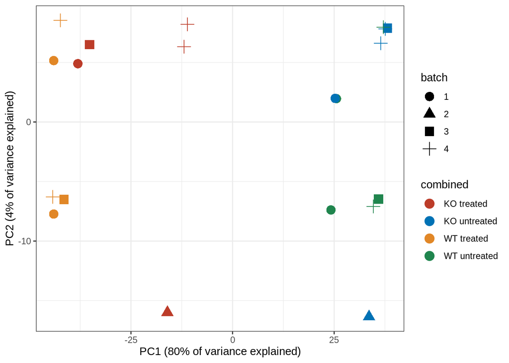

```r
pca = plotPCA_manual(object = vst(des),
                     intgroup = "combined",
                     pcs = 3,
                     merge_metadata = TRUE,
                     return_loadings = TRUE,
                     custom_annotation = mouse_conv)
ggplot(pca$data, aes(x = PC1, y = PC2, color = combined, shape = batch)) +
   geom_point(size = 4)  +
   scale_color_npg() +
   labs(x = paste0("PC1 (", pca$percent_var$percent_var[1], "% of variance explained)"),
        y = paste0("PC2 (", pca$percent_var$percent_var[2], "% of variance explained)")) +
   theme_bw(base_family = "Arial") +
   scale_color_nejm()
```

```
## which will replace the existing scale.
```

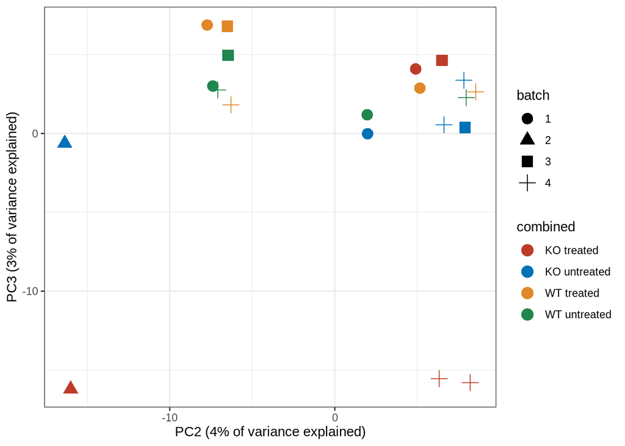

```r
ggplot(pca$data, aes(x = PC2, y = PC3, color = combined, shape = batch)) +
   geom_point(size = 4) +
   scale_color_npg() +
   labs(x = paste0("PC2 (", pca$percent_var$percent_var[2], "% of variance explained)"),
        y = paste0("PC3 (", pca$percent_var$percent_var[3], "% of variance explained)")) +
   theme_bw(base_family = "Arial") +
   scale_color_nejm()
```

PC1 is clearly treatment, and explains almost all of the variance in the data. Fairly limited separation by genotype that I can see. Need to confirm KO.

## Find best fit

```r
parametric = DESeq(des,
                   fitType = "parametric",
                   parallel = T)
```

```
##   Note: levels of factors in the design contain characters other than
##   letters, numbers, '_' and '.'. It is recommended (but not required) to use
##   only letters, numbers, and delimiters '_' or '.', as these are safe characters
##   for column names in R. [This is a message, not a warning or an error]
```

```
##   Note: levels of factors in the design contain characters other than
##   letters, numbers, '_' and '.'. It is recommended (but not required) to use
##   only letters, numbers, and delimiters '_' or '.', as these are safe characters
##   for column names in R. [This is a message, not a warning or an error]
```

```
##   Note: levels of factors in the design contain characters other than
##   letters, numbers, '_' and '.'. It is recommended (but not required) to use
##   only letters, numbers, and delimiters '_' or '.', as these are safe characters
##   for column names in R. [This is a message, not a warning or an error]
```

```
##   Note: levels of factors in the design contain characters other than
##   letters, numbers, '_' and '.'. It is recommended (but not required) to use
##   only letters, numbers, and delimiters '_' or '.', as these are safe characters
##   for column names in R. [This is a message, not a warning or an error]
```

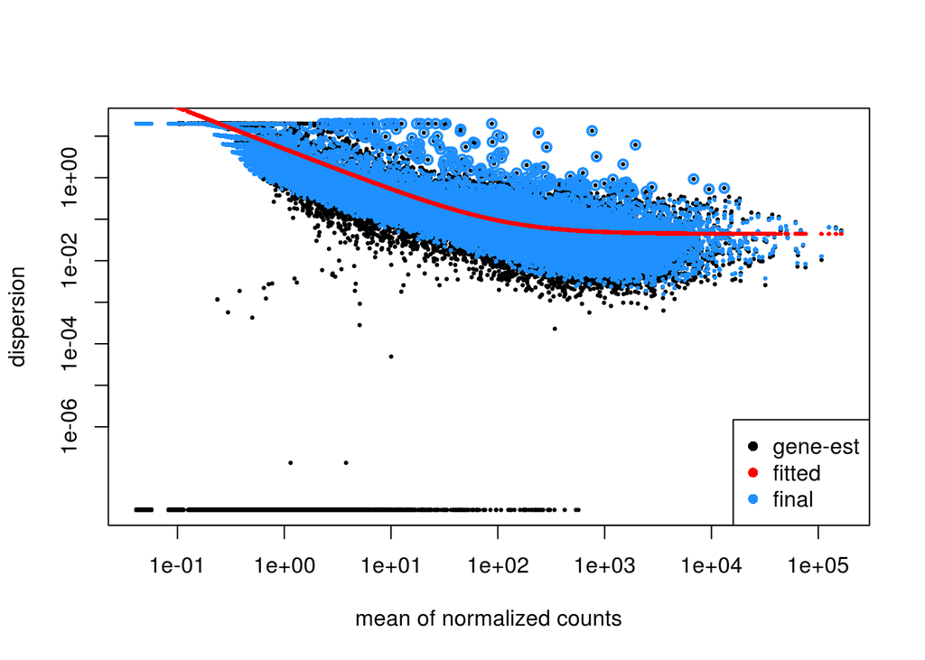

```r
plotDispEsts(parametric) #realistically this is pretty good
```

```r
local = DESeq(des,
              fitType = "local",
              parallel = T)
```

```
##   Note: levels of factors in the design contain characters other than
##   letters, numbers, '_' and '.'. It is recommended (but not required) to use
##   only letters, numbers, and delimiters '_' or '.', as these are safe characters
##   for column names in R. [This is a message, not a warning or an error]
```

```
##   Note: levels of factors in the design contain characters other than
##   letters, numbers, '_' and '.'. It is recommended (but not required) to use
##   only letters, numbers, and delimiters '_' or '.', as these are safe characters
##   for column names in R. [This is a message, not a warning or an error]
```

```
##   Note: levels of factors in the design contain characters other than
##   letters, numbers, '_' and '.'. It is recommended (but not required) to use
##   only letters, numbers, and delimiters '_' or '.', as these are safe characters
##   for column names in R. [This is a message, not a warning or an error]
```

```
##   Note: levels of factors in the design contain characters other than
##   letters, numbers, '_' and '.'. It is recommended (but not required) to use
##   only letters, numbers, and delimiters '_' or '.', as these are safe characters
##   for column names in R. [This is a message, not a warning or an error]
```

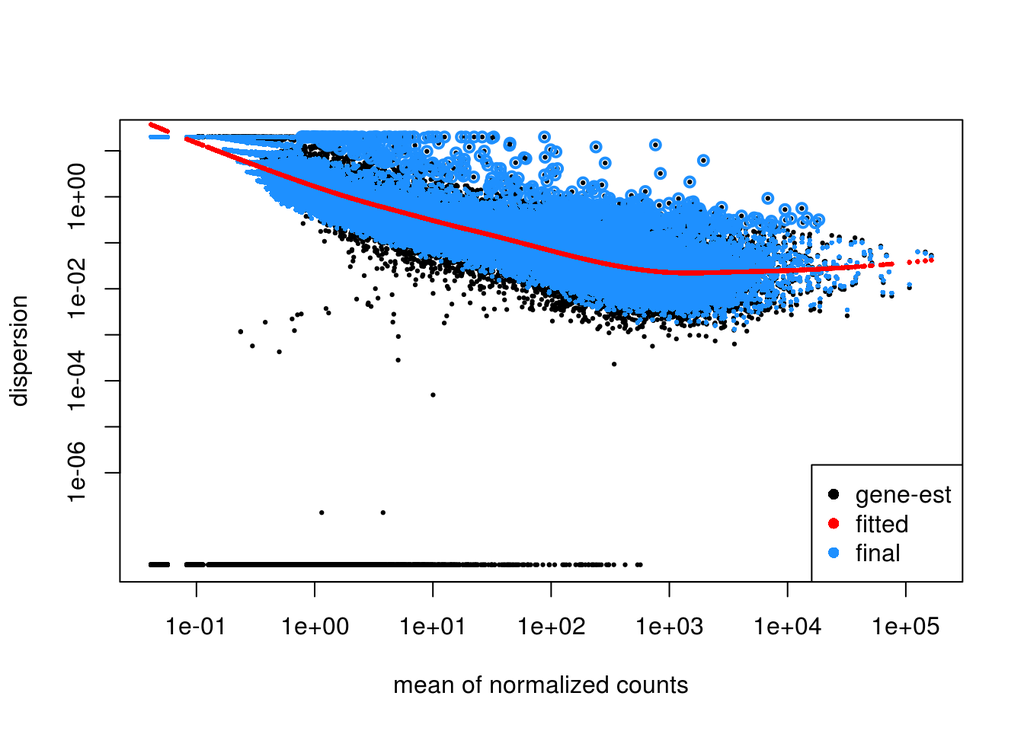

```r
plotDispEsts(local) #modestly better, keep
```

```r
dge = local
rm(local, parametric)
```

## Sanity checks

### Confirm KO

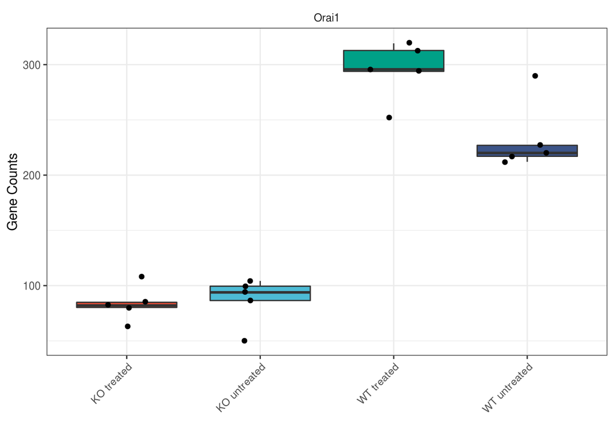

```r
orai1 = get_tidy_counts(obj = dge,
                        goi = c("Orai1"),
                        goi_format = "external_gene_name",
                        custom_annotation = mouse_conv)
ggplot(orai1, aes(x = combined, y = counts, fill = combined)) +
   facet_wrap(~external_gene_name, scales = "free_y") +
   geom_boxplot(outlier.shape = NA) +
   geom_jitter(width = 0.2) +
   scale_fill_npg() +
   theme_bw() +
   theme(strip.background = element_blank(),
        axis.text.x = element_text(angle = 45, hjust=1),
        legend.position = "none") +
  labs(x = "", y = "Gene Counts")
```

Appears to be some compensation going on, or maybe just other cell types in culture express, but expression is clearly reduced 2-3 fold.

# DEA

## KO, alone

### MA Plot

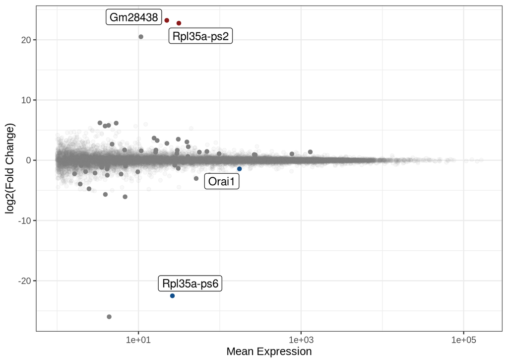

```r
Orai1_res = results(dge,
                    contrast = c("combined", "KO untreated", "WT untreated"),
                    alpha = 0.05,
                    parallel = T)

Orai1_hits = id_convert(Orai1_res, custom_annotation = mouse_conv)
write.csv(Orai1_hits, "~/Prakriya_Orai1_astro/data/211203_KO_hits_untreated.csv")

Orai1_hits = Orai1_res %>%
   as.data.frame() %>%
   dplyr::filter(padj < 0.05) %>%
   arrange(desc(log2FoldChange)) %>%
   id_convert(results = ., custom_annotation = mouse_conv)

Orai1_ma = pretty_MA_plot(results = Orai1_res, custom_annotation = mouse_conv) +
   theme_bw(base_family = "Arial") +
   theme(legend.position = "none")
Orai1_ma
```

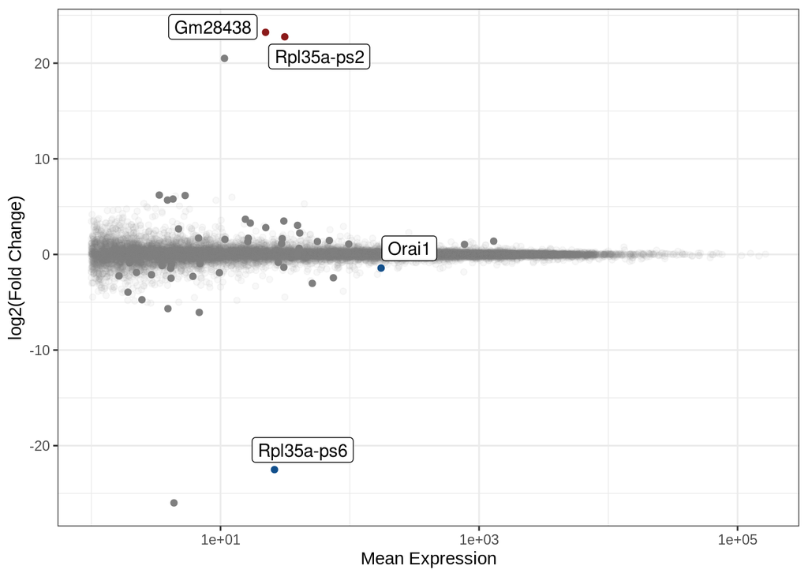

```r
CairoPDF("~/Prakriya_Orai1_astro/data/211203_Orai1_MA_untreated.pdf",
    width = 8,
    height = 6,
    family = "Arial")
Orai1_ma
```

```r
dev.off()
```

Very clean, but nothing beyond expected. Orai1 is downregulated the expected 2-3 fold, nothing else really changed.

## Treatment, alone

### MA Plot

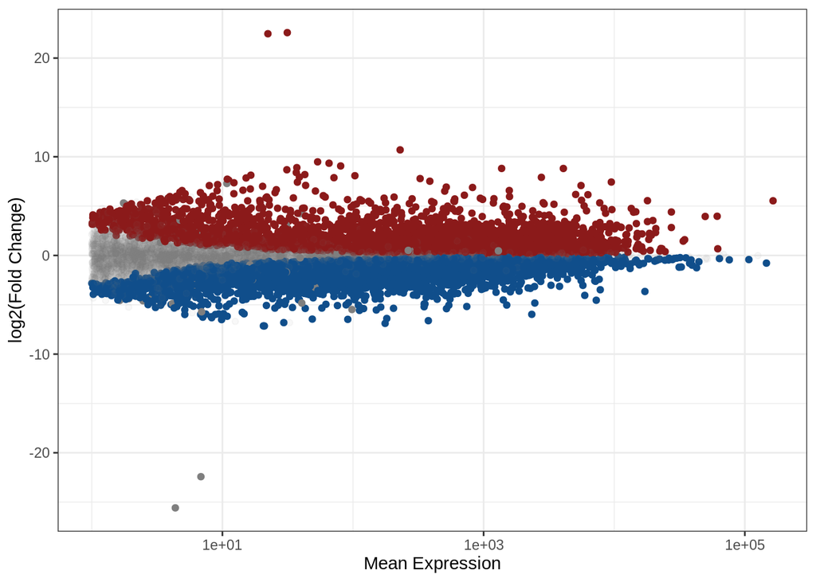

```r
treatment_res = results(dge,
                    contrast = c("combined", "WT treated", "WT untreated"),
                    alpha = 0.05,
                    parallel = T)

treatment_hits = id_convert(treatment_res, custom_annotation = mouse_conv)
write.csv(treatment_hits, "~/Prakriya_Orai1_astro/data/211203_treatment_hits_WT.csv")

treatment_hits = treatment_res %>%
   as.data.frame() %>%
   dplyr::filter(padj < 0.05) %>%
   arrange(desc(log2FoldChange)) %>%
   id_convert(results = ., custom_annotation = mouse_conv)

treatment_ma = pretty_MA_plot(results = treatment_res, custom_annotation = mouse_conv) +
   theme_bw(base_family = "Arial") +
   theme(legend.position = "none")
treatment_ma
```

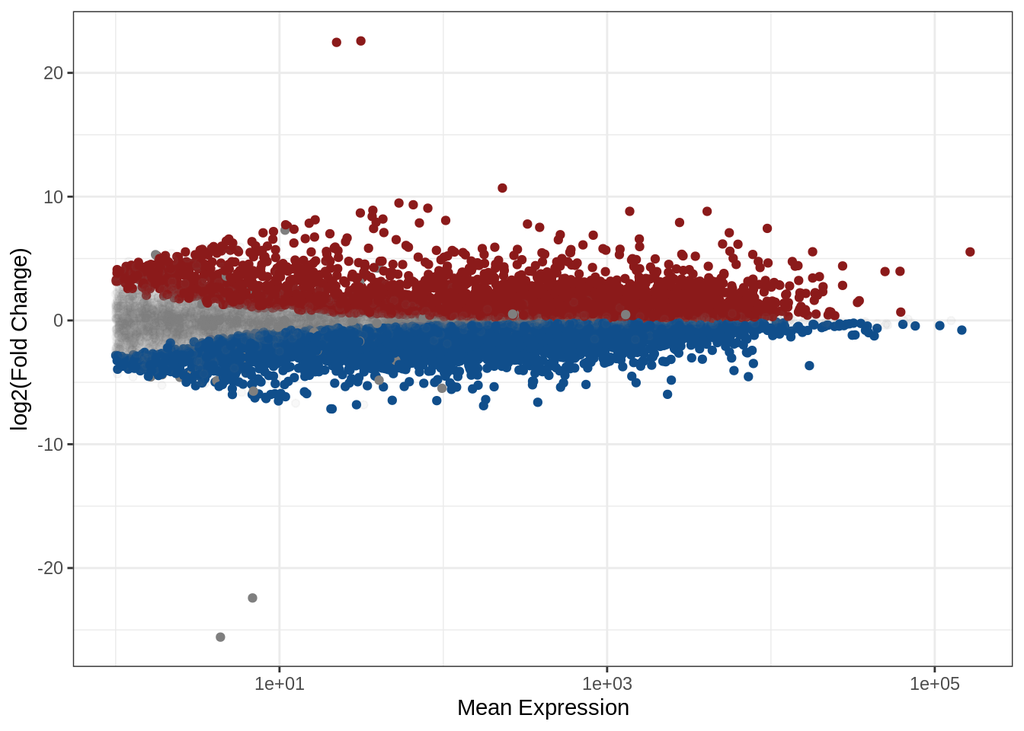

```r
CairoPDF("~/Prakriya_Orai1_astro/data/211203_treatment_MA_WT.pdf",
    width = 25,
    height = 15,
    family = "Arial")
treatment_ma
```

```r
dev.off()
```

Unsurprisingly, this perturbs the better part of the transcriptome. A total of 10840 genes are differentially expressed. Better to just look at the CSV in this case. Upregulated include a number of pro-inflammatory cytokines/signaling molecules (Cxcl2, Areg, Csf2), genes involved in maintaining a stem-like state or inibiting differentiation (Il11, LIF), and some potential astrocyte markers interestingly, including Aqp4? Canx, Calr, and HSPA5 are all up, which shows clear ER stress. Nothing immediately jumps out from downregulated genes, except Nanog, which again points to some shift in differentiation potential. Possible there are just some differentiating cells in these cultures which are pertubed by treatment alone or downstream inflammation.

### GO analysis

```r
treatment_go_up = go_enrichment(dge, goi = subset(treatment_hits, log2FoldChange > 0)$row.names)
```

```
##
## groupGOTerms:    GOBPTerm, GOMFTerm, GOCCTerm environments built.
```

```
##
## Building most specific GOs .....
```

```
##  ( 12399 GO terms found. )
```

```
##
## Build GO DAG topology ..........
```

```
##  ( 15866 GO terms and 36195 relations. )
```

```
##
## Annotating nodes ...............
```

```
##  ( 17812 genes annotated to the GO terms. )
```

```
##
##           -- Classic Algorithm --
##
##       the algorithm is scoring 12084 nontrivial nodes
##       parameters:
##           test statistic: Fisher test
```

```r
write.csv(treatment_go_up, "~/Prakriya_Orai1_astro/data/211203_treatment_wt_GO_up.csv")

treatment_go_down = go_enrichment(dge, goi = subset(treatment_hits, log2FoldChange < 0)$row.names)
```

```
##
## Building most specific GOs .....
```

```
##  ( 12399 GO terms found. )
```

```
##
## Build GO DAG topology ..........
```

```
##  ( 15866 GO terms and 36195 relations. )
```

```
##
## Annotating nodes ...............
```

```
##  ( 17812 genes annotated to the GO terms. )
```

```
##
##           -- Classic Algorithm --
##
##       the algorithm is scoring 11621 nontrivial nodes
##       parameters:
##           test statistic: Fisher test
```

```r
write.csv(treatment_go_down, "~/Prakriya_Orai1_astro/data/211203_treatment_wt_GO_down.csv")
```

Upregulated genes have strong RNA metabolism signature, as well as upregulation of cell survival pathways and protein folding machinery. Latter two make a lot of sense. Downregulated genes have strong signature of cytoskeletal remodeling and lipid metabolism, metabolism in general. This may just be a shift toward focus on protein quality control? I haven’t looked at this treatment much in the past.

## Treatment::Genotype

### MA Plot

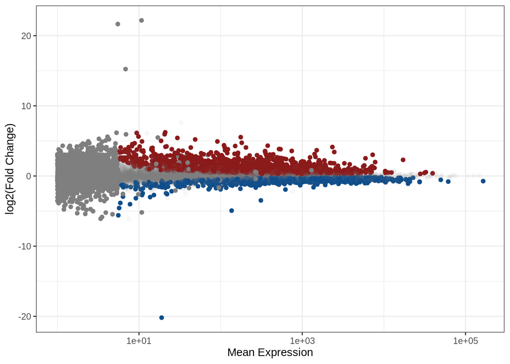

```r
interaction_res = results(dge,
                    contrast = c("combined", "KO treated", "WT treated"),
                    alpha = 0.05,
                    parallel = T)

interaction_hits = id_convert(interaction_res, custom_annotation = mouse_conv)
write.csv(interaction_hits, "~/Prakriya_Orai1_astro/data/211203_KOtreated_vs_WTtreated.csv")

interaction_hits = interaction_res %>%
   as.data.frame() %>%
   dplyr::filter(padj < 0.05) %>%
   arrange(desc(log2FoldChange)) %>%
   id_convert(results = ., custom_annotation = mouse_conv)

interaction_ma = pretty_MA_plot(results = interaction_res, custom_annotation = mouse_conv) +
   theme_bw(base_family = "Arial") +
   theme(legend.position = "none")
interaction_ma
```

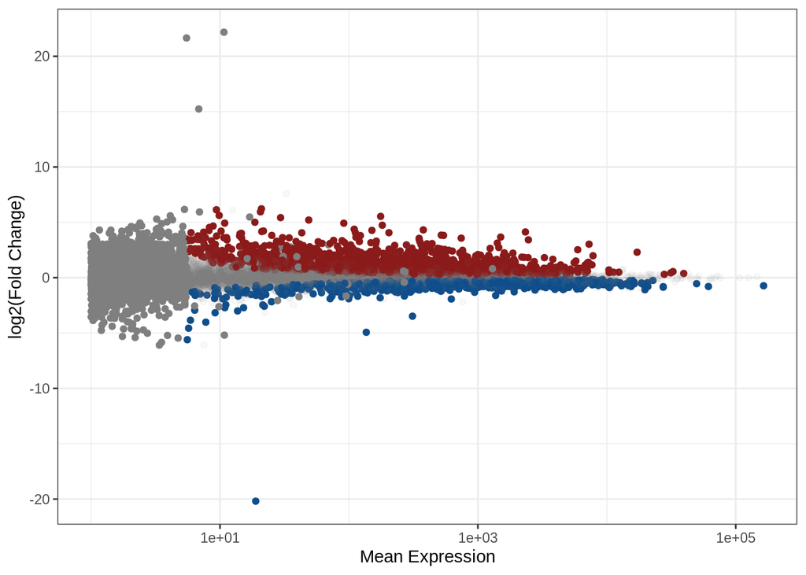

```r
CairoPDF("~/Prakriya_Orai1_astro/data/211203_KOtreated_vs_WTtreated.pdf",
    width = 25,
    height = 15,
    family = "Arial")
interaction_ma
```

```r
dev.off()
```

These are somewhat esoteric to me, better left to you. One thing that does jump out to me: the KO mounts less of a heat-shock-like response.

### GO analysis

```r
interaction_go_up = go_enrichment(dge, goi = subset(treatment_hits, log2FoldChange > 0)$row.names)
```

```
##
## Building most specific GOs .....
```

```
##  ( 12399 GO terms found. )
```

```
##
## Build GO DAG topology ..........
```

```
##  ( 15866 GO terms and 36195 relations. )
```

```
##
## Annotating nodes ...............
```

```
##  ( 17812 genes annotated to the GO terms. )
```

```
##
##           -- Classic Algorithm --
##
##       the algorithm is scoring 12084 nontrivial nodes
##       parameters:
##           test statistic: Fisher test
```

```r
write.csv(interaction_go_up, "~/Prakriya_Orai1_astro/data/211203_tKOtreated_vs_WTtreated_GO_up.csv")

interaction_go_down = go_enrichment(dge, goi = subset(treatment_hits, log2FoldChange < 0)$row.names)
```

```
##
## Building most specific GOs .....
```

```
##  ( 12399 GO terms found. )
```

```
##
## Build GO DAG topology ..........
```

```
##  ( 15866 GO terms and 36195 relations. )
```

```
##
## Annotating nodes ...............
```

```
##  ( 17812 genes annotated to the GO terms. )
```

```
##
##           -- Classic Algorithm --
##
##       the algorithm is scoring 11621 nontrivial nodes
##       parameters:
##           test statistic: Fisher test
```

```r
write.csv(interaction_go_down, "~/Prakriya_Orai1_astro/data/211203_KOtreated_vs_WTtreated_GO_down.csv")
```

### Heatmap of all hits across “combined” group (genotype and treatment)

Optimize k

```r
elbow = k_elbow(dge, design = "~ combined", cores = 12)
```

```
##   Note: levels of factors in the design contain characters other than
##   letters, numbers, '_' and '.'. It is recommended (but not required) to use
##   only letters, numbers, and delimiters '_' or '.', as these are safe characters
##   for column names in R. [This is a message, not a warning or an error]
```

```
##   Note: levels of factors in the design contain characters other than
##   letters, numbers, '_' and '.'. It is recommended (but not required) to use
##   only letters, numbers, and delimiters '_' or '.', as these are safe characters
##   for column names in R. [This is a message, not a warning or an error]
```

```
##   Note: levels of factors in the design contain characters other than
##   letters, numbers, '_' and '.'. It is recommended (but not required) to use
##   only letters, numbers, and delimiters '_' or '.', as these are safe characters
##   for column names in R. [This is a message, not a warning or an error]
```

```
##   Note: levels of factors in the design contain characters other than
##   letters, numbers, '_' and '.'. It is recommended (but not required) to use
##   only letters, numbers, and delimiters '_' or '.', as these are safe characters
##   for column names in R. [This is a message, not a warning or an error]
```

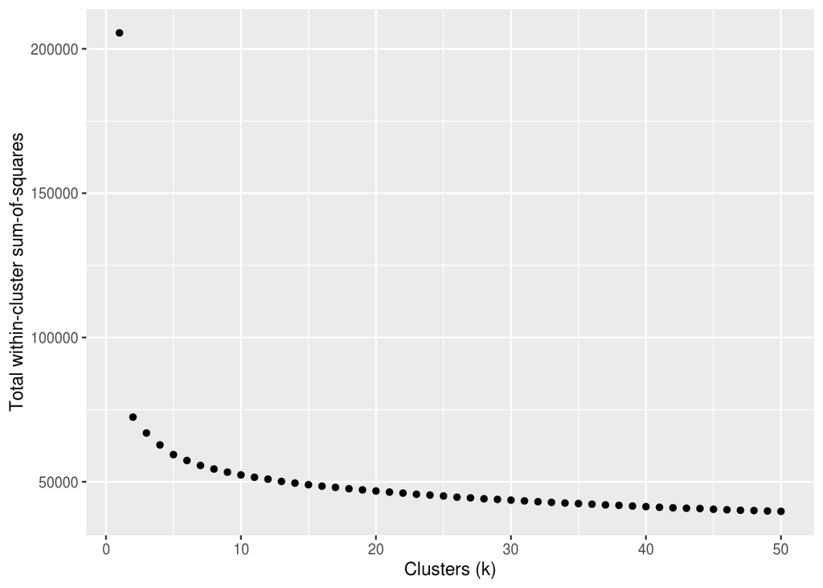

```r
elbow
```

4 looks reasonable, and makes sense with 4 conditions.

Generate plot and save

```r
k_means = k_means_figure(dge = dge,
                                 design = "~ combined",
                                 fitType = "local",
                                 k = 4,
                                 go_annotations = "org.Mm.eg.db",
                                 ensembl_db = "mmusculus_gene_ensembl",
                         #customAnno = mouse_conv,
                                 legend_factors = c("genotype", "treatment", "batch"),
                                 breaks = seq(-3, 3, length.out=101),
                                 cores = 1,
                                 return_genes = T,
                                 display_go_terms = F,
                                 return_go_terms = T,
                                 cluster_columns = T,
                                 show_rownames = F,
                                 qval_cutoff = 0.05,
                                 tidy_go = T)

saveRDS(k_means, "~/Prakriya_Orai1_astro/data/211203_combined_kmeans.rds")
write.csv(k_means$genes, "~/Prakriya_Orai1_astro/data/211203_kmeans_gene_assignments.csv")
write.csv(k_means$GO, "~/Prakriya_Orai1_astro/data/211203_kmeans_GO_enrichment.csv")
CairoPDF("~/Prakriya_Orai1_astro/data/211203_complete_kmeans.pdf",
    width = 8,
    height = 6,
    family = "Arial")
k_means$plot
dev.off()
```

Plot

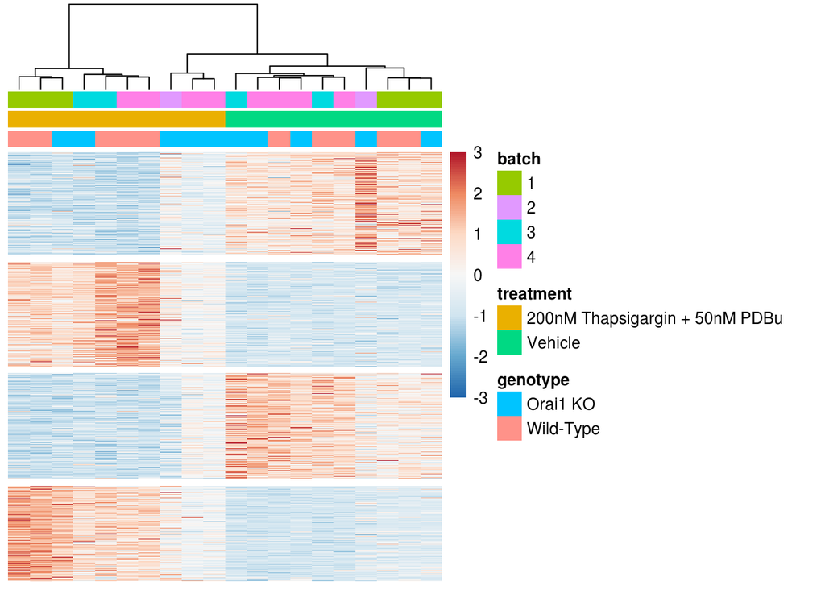

```r
k_means = readRDS("~/Prakriya_Orai1_astro/data/211203_combined_kmeans.rds")
k_means$plot
```

As expected, driven almost entirely by treatment. Still no obvious batch effect.